# Inference, etc Homework - Jacob Smith

Author

Jacob Smith

Published

November 5, 2025

```r
library(tidyverse)
library(ISLR2)
library(gt)
data(Carseats)
#view(Carseats)
```

## Problem 1

The first two problems in this set refer to the ISLR2::Carseats set, which includes simulated sample data for 400 stores selling a particular brand of child carseat. We view this data as a simple random sample from a larger population.

Does this data provide evidence against the company’s claim that the average price of their own seats is $110? Follow all best practices from class, including hypotheses, a relevant visualization, and a conclusion in non-technical language.

Null hypothesis: the average price of the company’s car seat is $110

Alternative hypothesis: the average price is not $110

```r
carseats_mean <- mean(Carseats$Price)
carseats_sd <- sd(Carseats$Price) # I created this because I wanted to include a bell curve on the graph below, but couldn't get it to work

carseats_table <- data.frame(statistic = c("Mean", "Standard Deviation"),
                             value = c(carseats_mean, carseats_sd))

carseats_table %>%
  gt() %>%
  tab_header(title = "Summary Statistics for Carseats Price") %>%
  fmt_number(columns = value,
             decimals = 2)
```

Summary Statistics for Carseats Price

| statistic | value |
| --- | --- |
| Mean | 115.79 |
| Standard Deviation | 23.68 |

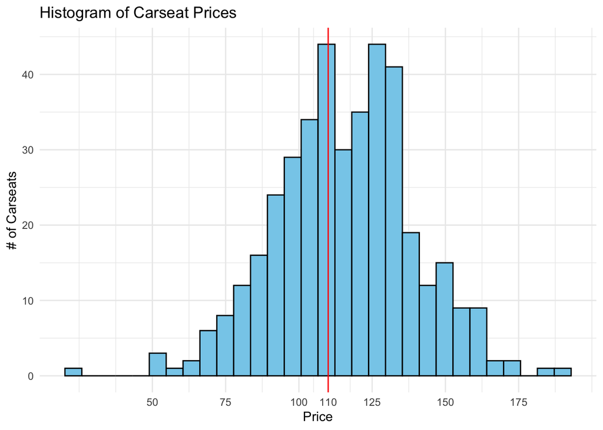

```r
ggplot(Carseats, aes(x = Price)) +
  geom_histogram(fill = "skyblue", color = "black") +
  geom_vline(xintercept = 110, color = "red") +
  scale_x_continuous(breaks = c(50, 75, 100, 110, 125, 150, 175),
                     labels = c("50", "75", "100", "110", "125", "150", "175")) +
  labs(title = "Histogram of Carseat Prices",
       x = "Price",
       y = "# of Carseats") +
  theme_minimal()
```

Conclusion: the average car seat is not $110, but rather 115.80 dollars.

## Problem 2

Compute a level 90% confidence interval for the mean competitor price in the population from which this sample is drawn. What is the sample mean? What is the margin of error?

```r
CSttests <- t.test(Carseats$CompPrice, conf.level = 0.90)

sample_mean <- CSttests$estimate
conf_int <- CSttests$conf.int
margin_error <- (conf_int[2] - conf_int[1]) / 2

cat("Sample mean:", round(sample_mean, 2),"Margin of error:", round(margin_error, 2), "\n")
```

```
Sample mean: 124.97 Margin of error: 1.26
```

## Problem 3

Use these tools to create a table with counts of penguin species and home islands in the penguins set. Include marginal counts in your table.

```r
data(penguins)
#view(penguins)

pentbl <- table(penguins$species, penguins$island)
addmargins(pentbl)
```

```
            Biscoe Dream Torgersen Sum
  Adelie        44    56        52 152
  Chinstrap      0    68         0  68
  Gentoo       124     0         0 124
  Sum          168   124        52 344
```

## Problem 4

[GitHub Repository](https://github.com/jacobsm1th5/math-250-github-sandbox)